# project1_RyanWang

2024-09-13

## Part 1

### 1

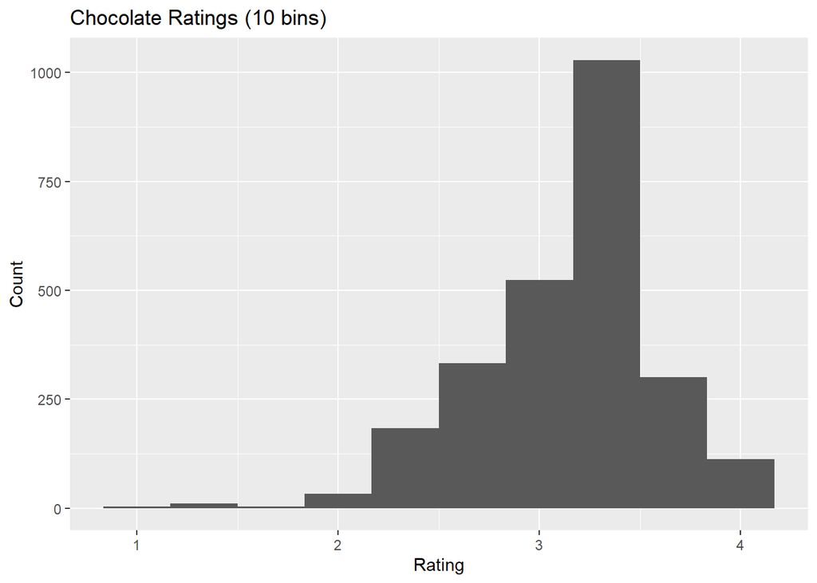

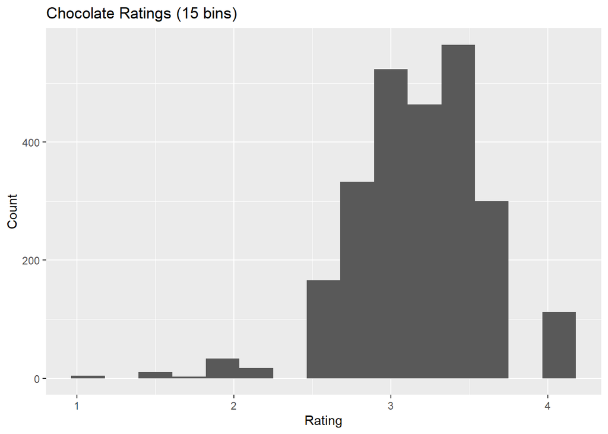

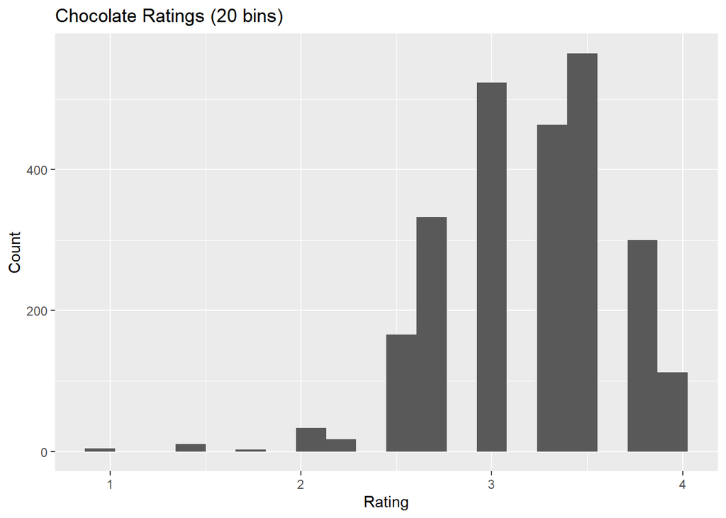

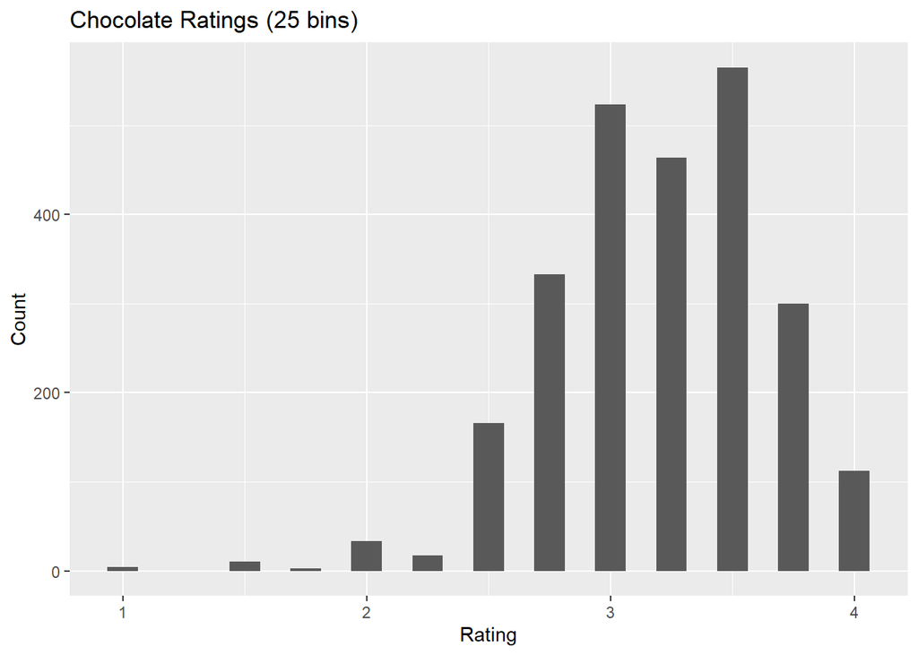

```r
for (i in c(10, 15, 20, 25)) {
  p <- ggplot2::ggplot(data = chocolate, mapping = aes(rating)) +
       geom_histogram(bins = i)  + # change the number of bins
       labs(x="Rating", y = "Count",
            title = paste("Chocolate Ratings (", i, " bins)", sep = ""))
  print(p)
}
```

```r
nlevels(as.factor(chocolate$rating))
```

```
## [1] 12
```

1. The bins argument sets the total number of bins. So, the four plots have number of bins of 10, 15, 20, 25 respectively. I would pick bins=15, because the variable rating has 12 levels. Choosing the number of bins to be close to it makes the bins neither too dispersive nor clustered together.

### 2

```r
# nlevels(as.factor(chocolate$country_of_bean_origin))
# levels(as.factor(chocolate$country_of_bean_origin))

reviews_count <- chocolate %>%
  count(country_of_bean_origin, sort = TRUE)

print(reviews_count)
```

```
## # A tibble: 62 × 2
##    country_of_bean_origin     n
##    <chr>                  <int>
##  1 Venezuela                253
##  2 Peru                     244
##  3 Dominican Republic       226
##  4 Ecuador                  219
##  5 Madagascar               177
##  6 Blend                    156
##  7 Nicaragua                100
##  8 Bolivia                   80
##  9 Colombia                  79
## 10 Tanzania                  79
## # ℹ 52 more rows
```

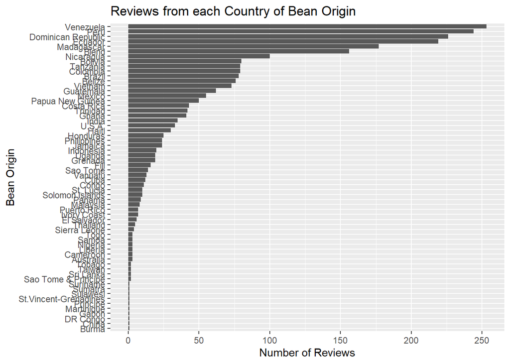

```r
ggplot(data=reviews_count, aes(y=n, x= with(reviews_count, reorder(country_of_bean_origin, n)))) +
  geom_col() + coord_flip() +
  labs(y="Number of Reviews", x="Bean Origin", title = "Reviews from each Country of Bean Origin")
```

### 3

```r
ecuador_rating <- chocolate %>% filter(country_of_bean_origin == "Ecuador")  # select Ecuador

rating_mean <- mean(ecuador_rating$rating)  # mean rating
rating_num <- length(ecuador_rating$rating)  # number of reviews
rating_sd <- sd(ecuador_rating$rating)  # standard deviation

ecuador_summary <- data.frame(rating_mean, rating_sd, rating_num)
colnames(ecuador_summary) <- c("mean", "sd", "total")

ecuador_summary %>% knitr::kable()
```

| mean | sd | total |
| --- | --- | --- |
| 3.164384 | 0.5122678 | 219 |

3. The average rating is 3.164, the standard deviation of the rating is 0.512. The total number of rating is 219.

### 4

```r
ecuador_rating_by_company <- ecuador_rating %>%
  group_by(company_location) %>%  # group by company
  summarize(rating_mean = mean(rating))  # mean rating

ecuador_rating_by_company_sorted <- ecuador_rating_by_company %>% arrange(desc(rating_mean))

best_choco_ecuador <- ecuador_rating_by_company_sorted[1:5,1]
print(best_choco_ecuador)
```

```
## # A tibble: 5 × 1
##   company_location
##   <chr>
## 1 Australia
## 2 Switzerland
## 3 New Zealand
## 4 Hungary
## 5 Israel
```

4. Australia has the highest average ratings of 3.81.

### 5

```r
choco_rating_by_origin_sorted <- chocolate %>%
  group_by(country_of_bean_origin) %>%  # group by origin
  summarize(rating_mean = mean(rating))%>% arrange(desc(rating_mean))

top_3_country <- choco_rating_by_origin_sorted[1:3,1]
print(top_3_country)
```

```
## # A tibble: 3 × 1
##   country_of_bean_origin
##   <chr>
## 1 Tobago
## 2 China
## 3 Sao Tome & Principe
```

5. The top 3 countries with highest ratings on average is Tobago, China, Sao Tome & Principe.

### 6

```r
choco_rating_num_by_origin <- chocolate %>%
  group_by(country_of_bean_origin) %>%  # group by origin
  summarize(rating_num = length(rating)) %>% filter(rating_num>=10)  # remove origins with less than 10 reviews

countries_with_10_ratings <- choco_rating_num_by_origin$country_of_bean_origin

chocolate_rating_filtered <- chocolate %>%
  filter(country_of_bean_origin %in% countries_with_10_ratings) %>%
  group_by(country_of_bean_origin) %>%
  summarize(rating_mean = mean(rating))%>% arrange(desc(rating_mean))

top_3_country_filtered <- chocolate_rating_filtered[1:3,1]
print(top_3_country_filtered)
```

```
## # A tibble: 3 × 1
##   country_of_bean_origin
##   <chr>
## 1 Solomon Islands
## 2 Congo
## 3 Cuba
```

6. Now, the to 3 countries with highest ratings are Solomon Islands, Congo, Cuba.

### 7

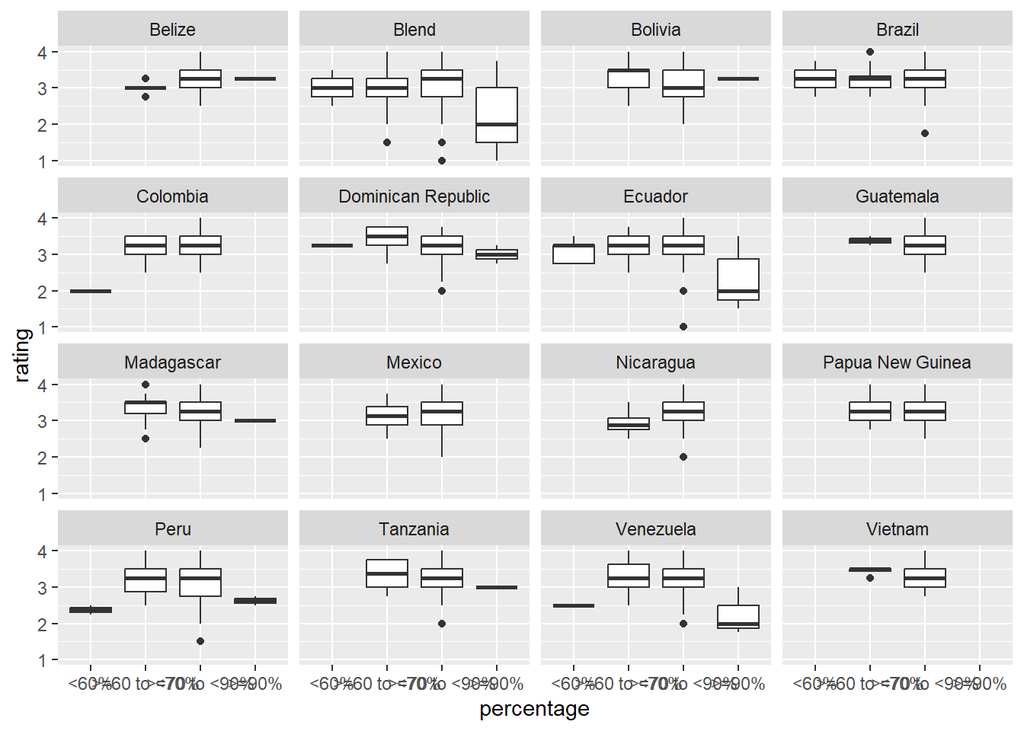

```r
choco_50rating_num_by_origin <- chocolate %>%
  group_by(country_of_bean_origin) %>%  # group by origin
  summarize(rating_num = length(rating)) %>% filter(rating_num>=50)  # at least 50 reviews

countries_with_50_ratings <- choco_50rating_num_by_origin$country_of_bean_origin

chocolate_50rating <- chocolate %>%
  filter(country_of_bean_origin %in% countries_with_50_ratings) %>% # countries with at least 50 reviews
  mutate(cocoa_percent_numeric = as.numeric(as.numeric(gsub("%", "", cocoa_percent)))) %>%
  mutate(percentage = case_when(cocoa_percent_numeric <60 ~ "<60%",
                      cocoa_percent_numeric>=60 & cocoa_percent_numeric<70 ~ ">=60 to <70%",
                      cocoa_percent_numeric>=70 & cocoa_percent_numeric<90 ~ ">=70 to <90%",
                                cocoa_percent_numeric>=90 ~ ">=90%")) %>%
  # new column that identify the percentages
  mutate(percentage = as.factor(percentage)) %>%
  mutate(percentage = fct_relevel(percentage, c("<60%", ">=60 to <70%", ">=70 to <90%", ">=90%"))) %>%
  arrange((cocoa_percent_numeric))

ggplot(chocolate_50rating, aes(y=rating, x=percentage)) + geom_boxplot() +
  facet_wrap(.~country_of_bean_origin)
```

```r
chocolate_rating_by_percent <- chocolate_50rating %>%
  group_by(percentage) %>%
  summarize(rating_mean = mean(rating))%>% arrange(desc(rating_mean))
print(chocolate_rating_by_percent)
```

```
## # A tibble: 4 × 2
##   percentage   rating_mean
##   <fct>              <dbl>
## 1 >=60 to <70%        3.25
## 2 >=70 to <90%        3.22
## 3 <60%                2.96
## 4 >=90%               2.49
```

```r
countries_with_60to70_percent <- chocolate_50rating %>%
  group_by(country_of_bean_origin, percentage) %>%
  summarize(rating_mean_by_percent = mean(rating)) %>%
  arrange(country_of_bean_origin, desc(rating_mean_by_percent)) %>%
  distinct(country_of_bean_origin, .keep_all = TRUE) %>% filter(percentage != ">=60 to <70%")
print(countries_with_60to70_percent)
```

```
## # A tibble: 7 × 3
## # Groups:   country_of_bean_origin [7]
##   country_of_bean_origin percentage   rating_mean_by_percent
##   <chr>                  <fct>                         <dbl>
## 1 Belize                 >=70 to <90%                   3.25
## 2 Blend                  >=70 to <90%                   3.12
## 3 Brazil                 >=70 to <90%                   3.27
## 4 Colombia               >=70 to <90%                   3.22
## 5 Ecuador                >=70 to <90%                   3.22
## 6 Mexico                 >=70 to <90%                   3.17
## 7 Nicaragua              >=70 to <90%                   3.28
```

The second category, “>= 60 to <70%” has the highest rating on average. A few countries have disagreements with this result, such as “Belize” “Blend” “Brazil” “Colombia” “Ecuador” “Mexico” “Nicaragua”.

## Part 2

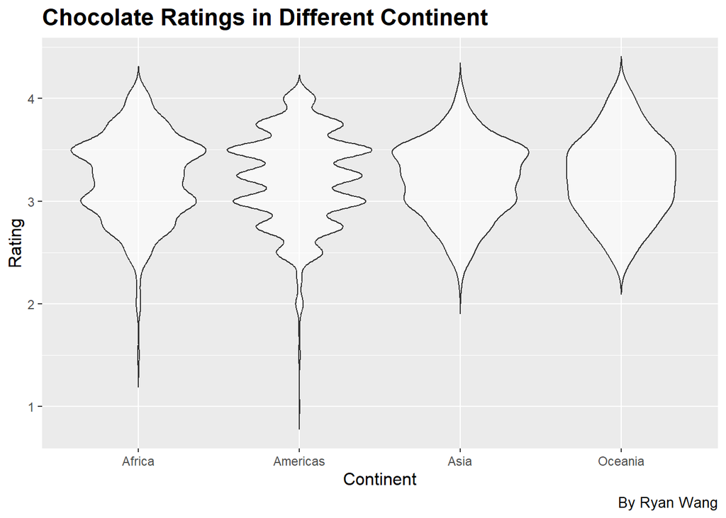

```r
gapminder_data <- gapminder %>% select(country, continent)
country_continent <- unique(gapminder_data)

chocolate_reviews_with_continent <- chocolate %>%
  left_join(country_continent, by = c("country_of_bean_origin" = "country"))

chocolate_reviews_with_continent <- chocolate_reviews_with_continent %>%
  group_by(country_of_bean_origin)  %>%  # group by origin
  filter(n()>=10) %>%  # at least 10 reviews
  filter(country_of_bean_origin != "Blend")  # remove blend

fill_continent <- c(
  "Belize" ="Americas",
  "Congo" ="Africa",
  "Fiji" ="Oceania",
  "Grenada" ="Americas",
  "Papua New Guinea" ="Oceania",
  "Sao Tome" ="Africa",
  "Solomon Islands" ="Oceania",
  "St. Lucia" ="Americas",
  "Trinidad" ="Americas",
  "U.S.A." ="Americas",
  "Vanuatu" ="Oceania"
)

chocolate_reviews_with_continent <-chocolate_reviews_with_continent %>%
  mutate(continent = ifelse(is.na(continent), as.character(fill_continent[country_of_bean_origin]), as.character(continent)))
# fill the na

chocolate_reviews_with_continent %>%
    ggplot(aes(
        x = as.factor(continent), y = rating)) +
    geom_violin(alpha = 0.6, trim = F) +
  labs(x = "Continent", y = "Rating", title = "Chocolate Ratings in Different Continent",
       caption = "By Ryan Wang")  +
  theme(
    plot.title = element_text(size = 16, face = "bold"),
    axis.title.x = element_text(size = 12),
    axis.title.y = element_text(size = 12),
    plot.caption = element_text(size = 10)
  )
```

## Part 3

```r
chocolate_part3 <- chocolate %>%
  mutate(ingredients = ifelse(is.na(ingredients), 'none', ingredients))%>%  # set ingredients to none if na
  mutate(
    beans = if_else(str_detect(ingredients, "B"), 1, 0),
    sugar = if_else(str_detect(ingredients, "S"), 1, 0),
    cocoa_butter = if_else(str_detect(ingredients, "C"), 1, 0),
    vanilla = if_else(str_detect(ingredients, "V"), 1, 0),
    lecithin = if_else(str_detect(ingredients, "L"), 1, 0),
    salt = if_else(str_detect(ingredients, "S"), 1, 0)  # 1
  ) %>%

  mutate(
    char_cocoa = if_else(str_detect(most_memorable_characteristics, "cocoa"), 1, 0),
    char_sweet = if_else(str_detect(most_memorable_characteristics, "sweet"), 1, 0),
    char_nutty = if_else(str_detect(most_memorable_characteristics, "nutty"), 1, 0),
    char_creamy = if_else(str_detect(most_memorable_characteristics, "creamy"), 1, 0),
    char_roasty = if_else(str_detect(most_memorable_characteristics, "roasty"), 1, 0),
    char_earthy = if_else(str_detect(most_memorable_characteristics, "earthy"), 1, 0)  # 2
  ) %>%

  group_by(review_date) %>%
  summarize(
    beans = mean(beans, na.rm = TRUE),
    sugar = mean(sugar, na.rm = TRUE),
    cocoa_butter = mean(cocoa_butter, na.rm = TRUE),
    vanilla = mean(vanilla, na.rm = TRUE),
    lecithin = mean(lecithin, na.rm = TRUE),
    salt = mean(salt, na.rm = TRUE),
    char_cocoa = mean(char_cocoa, na.rm = TRUE),
    char_sweet = mean(char_sweet, na.rm = TRUE),
    char_nutty = mean(char_nutty, na.rm = TRUE),
    char_creamy = mean(char_creamy, na.rm = TRUE),
    char_roasty = mean(char_roasty, na.rm = TRUE),
    char_earthy = mean(char_earthy, na.rm = TRUE)
  ) %>%

  pivot_longer(cols = c("beans", "sugar", "cocoa_butter", "vanilla", "lecithin",
                        "salt", "char_cocoa", "char_sweet", "char_nutty", "char_creamy",
                        "char_roasty", "char_earthy"),
               names_to = "feature",
               values_to = "mean_score")

head(chocolate_part3)
```

```
## # A tibble: 6 × 3
##   review_date feature      mean_score
##         <dbl> <chr>             <dbl>
## 1        2006 beans             0.968
## 2        2006 sugar             0.968
## 3        2006 cocoa_butter      0.903
## 4        2006 vanilla           0.694
## 5        2006 lecithin          0.694
## 6        2006 salt              0.968
```

## part 4

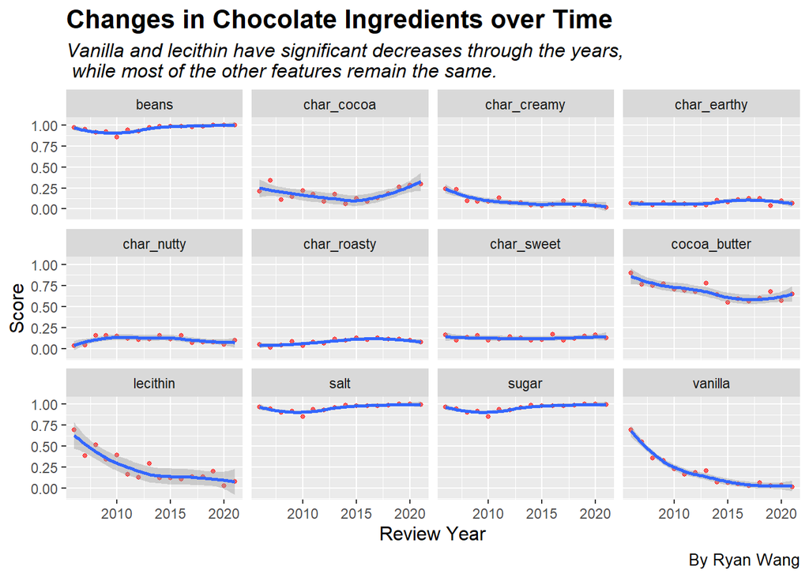

```r
ggplot(chocolate_part3, aes(y=mean_score, x=review_date)) + geom_point(color = "red", size = 1, alpha = 0.6) +
    geom_smooth(method = "loess", size = 1) + facet_wrap( ~ feature, nrow = 3) +
  labs(title = "Changes in Chocolate Ingredients over Time",
       subtitle = "Vanilla and lecithin have significant decreases through the years, \n while most of the other features remain the same.",
       x = "Review Year", y = "Score",
       caption = "By Ryan Wang") +
  theme(
    plot.title = element_text(size = 16, face = "bold"),
    plot.subtitle = element_text(size = 12, face = "italic"),
    axis.title.x = element_text(size = 12),
    axis.title.y = element_text(size = 12),
    plot.caption = element_text(size = 10)
  )
```